# UTLK Phosphorus Methods review

#### 4.23 Total Nitrogen

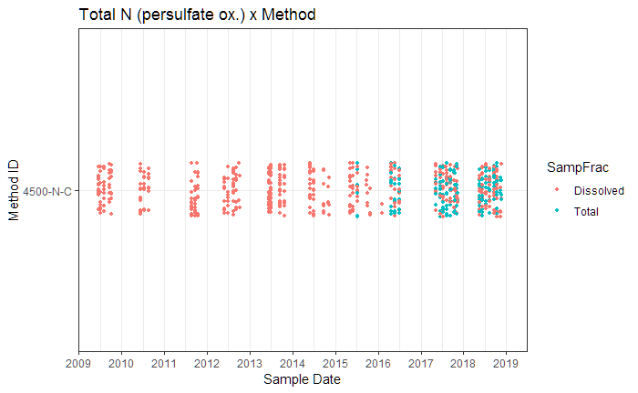

```r
N_data02 %>% filter(ParamX=="TN") %>%
  ggplot(.,
         aes(y=SDate,
             x=factor(MethodID),
             col=SampFrac)) + theme_bw() +
  geom_point(na.rm=T,
             position=position_jitter(width=0.1), size=1) +
  xlab("Method ID") + ylab("Sample Date") +
  scale_y_date(date_labels ="%Y",
               date_breaks="1 year",
               limits=c(as.Date(NA), as.Date("2019-01-01"))) +
  coord_flip() +
  ggtitle("Total N (persulfate ox.) x Method")
```

- Reporting Limits

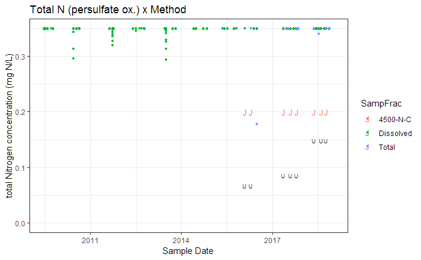

```r
(
N_data02 %>% filter(ParamX=="TN") %>%
  ggplot(.,
         aes(x=SDate,
             y=as.numeric(Result.Value),
             col=SampFrac)) + theme_bw() +
  geom_point(na.rm=T,
             position=position_jitter(width=0.05), size=1) +
  geom_point(data=N_data02%>%filter(ParamX=="TN")%>%distinct(samp_YRqtr, .keep_all=T), na.rm=T,
             aes(x=SDate, y=LRL, color=MethodID), shape="J", size=3) +
  geom_point(data=N_data02%>%filter(ParamX=="TN")%>%distinct(samp_YRqtr, .keep_all=T), na.rm=T,
             aes(x=SDate, y=MDL), color="black", shape="U", size=2) +
  xlab("Sample Date") + ylab("total Nitrogen concentration (mg N/L)") +
  scale_x_date(date_labels ="%Y",
               date_breaks="3 year",
               limits=c(as.Date(NA), as.Date("2019-01-01"))) +
  scale_y_continuous(oob=squish,
                     limits=c(0, 0.35)) +
  ggtitle("Total N (persulfate ox.) x Method")
)
```

#### 4.24 Kjeldahl N

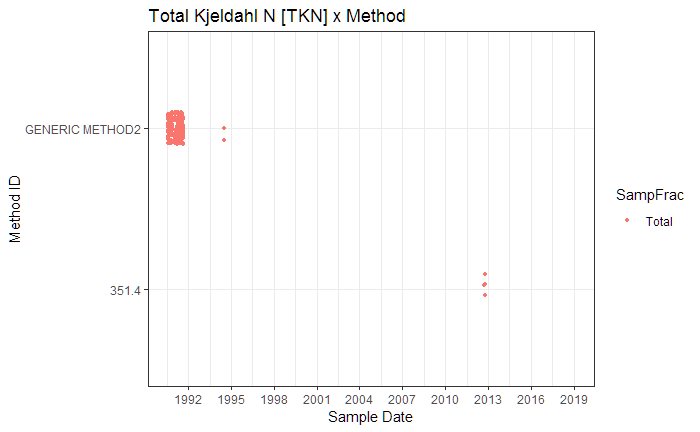

```r
N_data02 %>% filter(ParamX=="TKN") %>%
  ggplot(.,
         aes(y=SDate,
             x=factor(MethodID),
             col=SampFrac)) + theme_bw() +
  geom_point(na.rm=T,
             position=position_jitter(width=0.1), size=1) +
  xlab("Method ID") + ylab("Sample Date") +
  scale_y_date(date_labels ="%Y",
               date_breaks="3 year",
               limits=c(as.Date(NA), as.Date("2019-01-01"))) +
  coord_flip() +
  ggtitle("Total Kjeldahl N [TKN] x Method")
```

- Reporting Limits

```r
N_data02 %>% filter(ParamX=="TKN") %>% filter(is.na(Result.Value)) %>% nrow()
```

```
[1] 0
```

- No reporting limits given for TKN

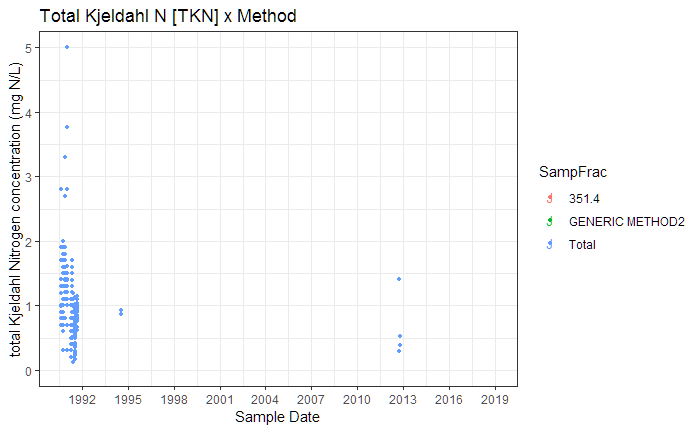

```r
(
N_data02 %>% filter(ParamX=="TKN") %>%
  ggplot(.,
         aes(x=SDate,
             y=as.numeric(Result.Value),
             col=SampFrac)) + theme_bw() +
  geom_point(na.rm=T,
             position=position_jitter(width=0.05), size=1) +
  geom_point(data=N_data02%>%filter(ParamX=="TKN")%>%distinct(samp_YRqtr, .keep_all=T), na.rm=T,
             aes(x=SDate, y=LRL, color=MethodID), shape="J", size=3) +
  geom_point(data=N_data02%>%filter(ParamX=="TKN")%>%distinct(samp_YRqtr, .keep_all=T), na.rm=T,
             aes(x=SDate, y=MDL), color="black", shape="U", size=2) +
  xlab("Sample Date") + ylab("total Kjeldahl Nitrogen concentration (mg N/L)") +
  scale_x_date(date_labels ="%Y",
               date_breaks="3 year",
               limits=c(as.Date(NA), as.Date("2019-01-01"))) +
  scale_y_continuous(oob=squish,
                     limits=c(0, NA)) +
  ggtitle("Total Kjeldahl N [TKN] x Method")
)
```

#### 4.25 Organic N

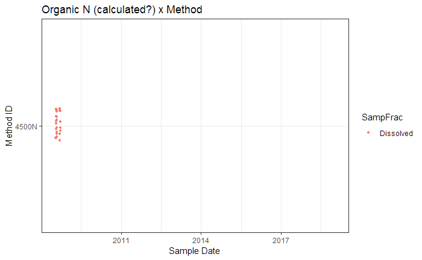

```r
N_data02 %>% filter(ParamX=="Norg") %>%
  ggplot(.,
         aes(y=SDate,
             x=factor(MethodID),
             col=SampFrac)) + theme_bw() +
  geom_point(na.rm=T,
             position=position_jitter(width=0.1), size=1) +
  xlab("Method ID") + ylab("Sample Date") +
  scale_y_date(date_labels ="%Y",
               date_breaks="3 year",
               limits=c(as.Date(NA), as.Date("2019-01-01"))) +
  coord_flip() +
  ggtitle("Organic N (calculated?) x Method")
```

- Few samples, no reporting limits given

## 5.0 Additional Param x Methods review

- [190714]

### 5.1 Full record sets of N-species in available dataset

Objective: Tabulate all record sets that have a full complement of soluble / suspended N species

- Rebuild Param x Fraction table…

```r
N_data02 %>% {addmargins(table(.$PARAM, .$SampFrac, useNA="ifany"))}
```

```
                                           Dissolved Total  Sum
  Ammonia-nitrogen                               138  1098 1236
  Inorganic nitrogen (nitrate and nitrite)      1004   162 1166
  Kjeldahl nitrogen                                0   259  259
  Nitrogen                                       506   170  676
  Organic Nitrogen                                25     0   25
  Sum                                           1673  1689 3362
```

- Ignore “Organic N”, too few observations to be useful
- Full S-sets ::
  - NH4 & NO32 & TN/TKN :: by fraction

```r
N_data02 %>%
  filter(PARAM != "Organic N") %>%
  filter(ACT.depth != "Bottom") %>%
  mutate(
    RVal2 = case_when(
      !is.na(Result.Value) ~ as.character(Result.Value),
      is.na(Result.Value) & !is.na(LRL) ~ "J",
      is.na(Result.Value) & !is.na(MDL) ~ "U",
      TRUE ~ as.character(NA))
    ) %>%
  select(-Method_desc, -AnalysisDate, -BatchID, -PROJ02, -PROJ01,
         -Organization.ID, -Activity.Media, -Activity.Depth.Height,
         -Activity.Depth.Height.Unit, -Activity.Top.Depth.Height,
         -Activity.Top.Depth.Height.Unit, -Activity.Bottom.Depth.Height,
         -Activity.Bottom.Depth.Height.Unit, -Activity.Conducting.Organization2,
         -ORG, -Sample.Collection.Method.ID, -Sample.Collection.Method.Context,
         -Sample.Collection.Method.Name, -Sample.Collection.Method.Description,
         -Result.UID, -Result.Depth.Height, -Result.Depth.Height.Unit,
         -Time.Basis, -Temperature.Basis, -AnalysisDate,
         -Analytical.Method.Context, -Analytical.Method.Name, -Analytical.Method.Qualifier,
         -Analysis.Start.Time, -Analysis.Start.Time.Zone, -LAB, -DLL,
         -MethPar.key, -PARAM, -Method.Speciation, -MethodID, -SampFrac, -ParamX,
         -LRL, -MDL, -DilFact, -DetCond, -Value.Type, -Result.Status, -ResQual,
         -Laboratory.Comment.Code, -Laboratory.Accreditation.Indicator,
         -ACT.depth, -Result.Comment, -ACT.comment, -ACT.type,
         -Lab.Sample.ID, -MLID.type, -contains("Limit", ignore.case = T),
         -Result.Value) %>%
  distinct(SDate, MLID, STime, Par_frac, .keep_all = T) %>%
  spread(., Par_frac, RVal2) %>%
  arrange(MLID, SDate) %>%
  select(-samp_YRqtr,
         -MLID.name, -ACTID, everything()) %>%
  select(MLID, SDate, STime, NH4.dis:TN.TOT,
         everything()) -> N_data03
#
 # select(-Method_desc, -AnalysisDate, -BatchID, -PROJ02, -PROJ01,
 #         -Organization.ID, -Activity.Media, -Activity.Depth.Height,
 #         -Activity.Depth.Height.Unit, -Activity.Top.Depth.Height,
 #         -Activity.Top.Depth.Height.Unit, -Activity.Bottom.Depth.Height,
 #         -Activity.Bottom.Depth.Height.Unit, -Activity.Conducting.Organization2,
 #         -ORG, -Sample.Collection.Method.ID, -Sample.Collection.Method.Context,
 #         -Sample.Collection.Method.Name, -Sample.Collection.Method.Description,
 #         -Result.UID, -Result.Depth.Height, -Result.Depth.Height.Unit,
 #         -Time.Basis, -Temperature.Basis, -AnalysisDate,
 #         -Analytical.Method.Context, -Analytical.Method.Name, -Analytical.Method.Qualifier,
 #         -Analysis.Start.Time, -Analysis.Start.Time.Zone, -LAB, -DLL) %>%
```

- Review spread/cast dataset [`N_data03`]

```r
N_data03 %>% nrow()
```

```
[1] 737
```

```r
N_data03 %>%
  distinct(ACTID) %>%
  nrow()
```

```
[1] 737
```

```r
N_data03 %>%
  distinct(ACTID, MLID) %>%
  nrow()
```

```
[1] 737
```

Looks like we have unique sampling-events for parameter comparisons…

- Using RVal2 as_char and includes J/U-flags to show when a sample was collected but the analyte was not detected…
- Sample.Collection intensity by MLID

```r
N_data03 %>% {
  addmargins(table(.$MLID, useNA="ifany", deparse.level = 2)) } %>%
  as.data.frame(.) %>% htmlTable::htmlTable(., css.cell = rbind(rep("padding-left: 0.8em; padding-right: 0.8em;font-size: 0.75em;", times=ncol(.)+1), matrix("padding-left: 0.75em; padding-right: 0.75em; font-size: 0.75em;", ncol=ncol(.)+1, nrow=nrow(.))), align="rcc", total=T)
```

|  | ..MLID | Freq |
| --- | --- | --- |
| 1 | 4917300 | 4 |
| 2 | 4917310 | 78 |
| 3 | 4917320 | 73 |
| 4 | 4917330 | 13 |
| 5 | 4917340 | 17 |
| 6 | 4917370 | 72 |
| 7 | 4917380 | 13 |
| 8 | 4917390 | 73 |
| 9 | 4917400 | 13 |
| 10 | 4917410 | 13 |
| 11 | 4917420 | 13 |
| 12 | 4917433 | 1 |
| 13 | 4917450 | 37 |
| 14 | 4917470 | 2 |
| 15 | 4917500 | 73 |
| 16 | 4917510 | 12 |
| 17 | 4917520 | 74 |
| 18 | 4917600 | 35 |
| 19 | 4917620 | 14 |
| 20 | 4917700 | 13 |
| 21 | 4917710 | 28 |
| 22 | 4917770 | 66 |
| 23 | Sum | 737 |

#### PLOT: MLID x Sample-Year

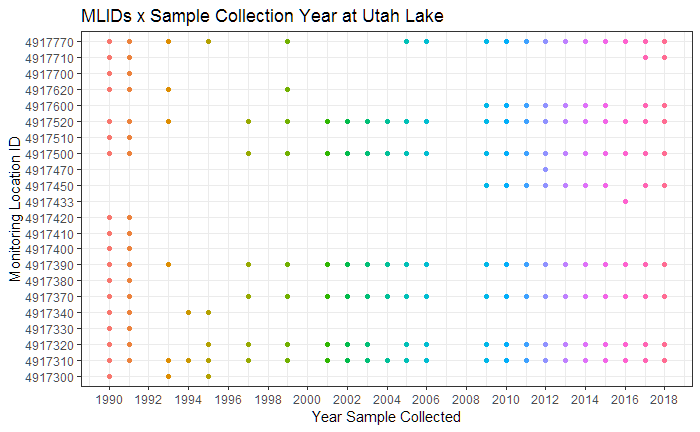

```r
N_data03 %>%
  ggplot(.,
         aes(x=lubridate::year(SDate),
             y = as.factor(MLID),
             col=as.character(lubridate::year(SDate)))) + theme_bw() +
  geom_point(na.rm=T) + theme(legend.position = "none") +
  xlab("Year Sample Collected") +
  ylab("Monitoring Location ID") +
  scale_x_continuous(limits=c(NA, NA), breaks = seq(1990, 2019, 2)) +
  ggtitle("MLIDs x Sample Collection Year at Utah Lake")
```

- Key Sampling Locations ::
  - 4917770
  - 4917600
  - 4917520
  - 4917500
  - 4917450
  - 4917390
  - 4917370
  - 4917320
  - 4917310

```r
key_sites <- c("4917770", "4917600", "4917520", "4917500",
               "4917450", "4917390", "4917370", "4917320", "4917310")
```

```r
N_data03_keysites <- N_data03 %>%
  filter(MLID %in% key_sites)
```

#### PLOT: MLID x Param

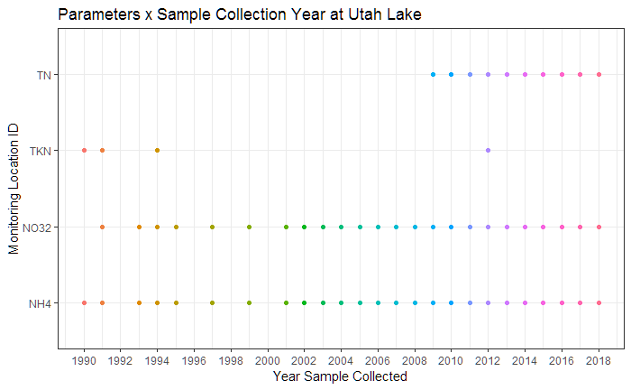

```r
N_data02 %>%
  filter(MLID %in% key_sites &
           ParamX != "Norg") %>%
  ggplot(.,
         aes(x=lubridate::year(SDate),
             y = as.factor(ParamX),
             col=as.character(lubridate::year(SDate)))) + theme_bw() +
  geom_point(na.rm=T) + theme(legend.position = "none") +
  xlab("Year Sample Collected") +
  ylab("Monitoring Location ID") +
  scale_x_continuous(limits=c(NA, NA), breaks = seq(1990, 2019, 2)) +
  ggtitle("Parameters x Sample Collection Year at Utah Lake")
```

#### tables

- Use DF: `N_data02`
  - Ignore organic N (*Norg*)

```r
N_data02 %>%
  filter(ParamX != "Norg") %>%
  {
  addmargins(table(.$MLID,
                   .$ParamX,
                   useNA="ifany", deparse.level = 2)) } %>%
  as.data.frame.matrix(.) %>% htmlTable::htmlTable(., css.cell = rbind(rep("padding-left: 0.8em; padding-right: 0.8em;font-size: 0.75em;", times=ncol(.)+1), matrix("padding-left: 0.75em; padding-right: 0.75em; font-size: 0.75em;", ncol=ncol(.)+1, nrow=nrow(.))), align="rcc", total=T)
```

|  | NH4 | NO32 | TKN | TN | Sum |
| --- | --- | --- | --- | --- | --- |
| 4917300 | 3 | 0 | 1 | 0 | 4 |
| 4917310 | 147 | 143 | 21 | 74 | 385 |
| 4917320 | 116 | 112 | 21 | 70 | 319 |
| 4917330 | 13 | 9 | 12 | 0 | 34 |
| 4917340 | 19 | 14 | 14 | 0 | 47 |
| 4917370 | 142 | 141 | 20 | 79 | 382 |
| 4917380 | 14 | 9 | 12 | 0 | 35 |
| 4917390 | 145 | 139 | 13 | 89 | 386 |
| 4917400 | 13 | 9 | 12 | 0 | 34 |
| 4917410 | 13 | 9 | 12 | 0 | 34 |
| 4917420 | 13 | 9 | 12 | 0 | 34 |
| 4917433 | 2 | 2 | 0 | 2 | 6 |
| 4917450 | 57 | 60 | 2 | 53 | 172 |
| 4917470 | 2 | 4 | 2 | 2 | 10 |
| 4917500 | 142 | 136 | 15 | 84 | 377 |
| 4917510 | 12 | 8 | 11 | 0 | 31 |
| 4917520 | 131 | 129 | 11 | 74 | 345 |
| 4917600 | 56 | 58 | 0 | 53 | 167 |
| 4917620 | 21 | 17 | 17 | 0 | 55 |
| 4917700 | 17 | 11 | 13 | 0 | 41 |
| 4917710 | 42 | 37 | 13 | 28 | 120 |
| 4917770 | 116 | 110 | 25 | 68 | 319 |
| Sum | 1236 | 1166 | 259 | 676 | 3337 |

- Look at only key sites…
- Summarize N-species sets for key_sites

```r
N_data03_keysites %<>% mutate(
  full_N = case_when(
    (!is.na(NH4.dis) | !is.na(NH4.TOT)) &
      (!is.na(NO32.dis) | !is.na(NO32.TOT)) &
      (!is.na(TKN.TOT) | !is.na(TN.dis) | !is.na(TN.TOT)) ~ "YES",
    TRUE ~ "no")) %>%
  select(MLID:TN.TOT, full_N, everything())
```

```r
N_data03_keysites %>% {addmargins(table(.$MLID, .$full_N,
                                        useNA="ifany", deparse.level = 2))}
```

```
         .$full_N
.$MLID     no YES Sum
  4917310  23  55  78
  4917320  19  54  73
  4917370  19  53  72
  4917390  21  52  73
  4917450   1  36  37
  4917500  21  52  73
  4917520  22  52  74
  4917600   0  35  35
  4917770  14  52  66
  Sum     140 441 581
```

```r
#
N_data03_keysites %>%
  filter(full_N == "YES") %>%
  {addmargins(table(.$MLID, lubridate::year(.$SDate),
                                        useNA="ifany", deparse.level = 2))}
```

```
         lubridate::year(.$SDate)
.$MLID    1991 1994 2009 2010 2011 2012 2013 2014 2015 2016 2017 2018 Sum
  4917310    9    1    5    3    3    4    4    4    5    3    7    7  55
  4917320    9    0    5    3    3    4    4    4    5    3    7    7  54
  4917370    9    0    5    3    3    4    4    4    4    3    7    7  53
  4917390    9    0    5    3    3    4    3    3    5    3    7    7  52
  4917450    0    0    5    3    3    6    3    1    2    0    7    6  36
  4917500    8    0    5    3    3    4    4    4    4    3    7    7  52
  4917520    8    0    5    3    3    4    4    4    4    3    7    7  52
  4917600    0    0    5    3    3    4    3    2    2    0    7    6  35
  4917770    9    0    5    3    3    4    3    4    4    3    7    7  52
  Sum       61    1   45   27   27   38   32   30   35   21   63   61 441
```

- Approximate “*completeness*” of N-species by MLID (key sites only [9]) by Year is higher than expected :: 76% of sample-collections have full N-species

### 5.2 Sample Fraction Efx on N-species

- From table in 5.1, not a whole lot of paired inorganic N-species
- Working DF :: `N_data02`

#### NH4 x Sample Fraction

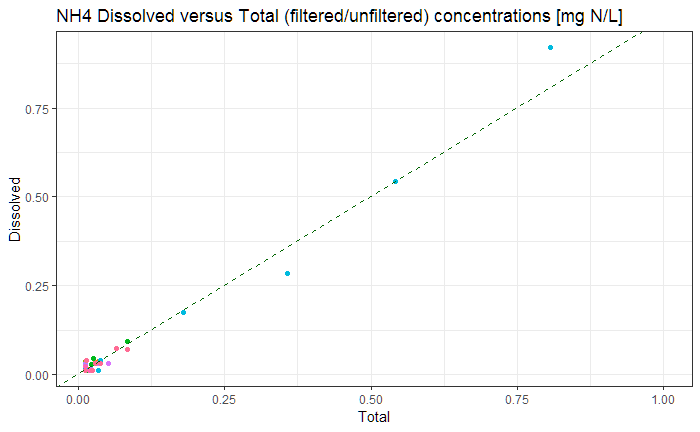

```r
N_data02 %>%
  filter(ParamX=="NH4" & ACT.depth != "Bottom") %>%
  mutate(
    RVal2 = case_when(
      !is.na(Result.Value) ~ as.numeric(Result.Value),
      is.na(Result.Value) & !is.na(MDL) ~ as.numeric(MDL),
      is.na(Result.Value) & !is.na(LRL) ~ as.numeric(LRL),
      TRUE ~ as.numeric(NA)),
    Rflag = case_when(
      is.na(Result.Value) & !is.na(MDL) ~ "U",
      is.na(Result.Value) & !is.na(LRL) ~ "J",
      TRUE ~ as.character(NA))
    ) %>%
  distinct(MLID, ParamX, SDate, SampFrac, RVal2, ACT.depth,
         MethodID) %>%
  spread(., SampFrac, RVal2) %>%
  ggplot(.,
         aes(x=Total, y=Dissolved,
             col=MLID)) + theme_bw() +
  geom_point(na.rm=T) + theme(legend.position = "none") +
  ggtitle("NH4 Dissolved versus Total (filtered/unfiltered) concentrations [mg N/L]") +
  geom_abline(slope=1, intercept=0, lty=2, col="darkgreen") +
  scale_x_continuous(limits=c(NA, 1), oob=squish) +
  scale_y_continuous(limits=c(NA, NA), oob=squish)
```

#### NO32 x Sample Fraction

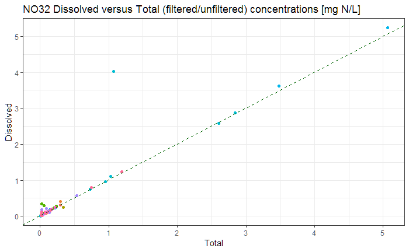

```r
N_data02 %>%
  filter(ParamX=="NO32" & ACT.depth != "Bottom") %>%
  mutate(
    RVal2 = case_when(
      !is.na(Result.Value) ~ as.numeric(Result.Value),
      is.na(Result.Value) & !is.na(MDL) ~ as.numeric(MDL),
      is.na(Result.Value) & !is.na(LRL) ~ as.numeric(LRL),
      TRUE ~ as.numeric(NA)),
    Rflag = case_when(
      is.na(Result.Value) & !is.na(MDL) ~ "U",
      is.na(Result.Value) & !is.na(LRL) ~ "J",
      TRUE ~ as.character(NA))
    ) %>%
  distinct(MLID, ParamX, SDate, SampFrac, RVal2, ACT.depth,
         MethodID) %>%
  spread(., SampFrac, RVal2) %>%
  ggplot(.,
         aes(x=Total, y=Dissolved,
             col=MLID)) + theme_bw() +
  geom_point(na.rm=T) + theme(legend.position = "none") +
  ggtitle("NO32 Dissolved versus Total (filtered/unfiltered) concentrations [mg N/L]") +
  geom_abline(slope=1, intercept=0, lty=2, col="darkgreen") +
  scale_x_continuous(limits=c(NA, NA), oob=squish) +
  scale_y_continuous(limits=c(NA, NA), oob=squish)
```

- Across all available UTLK data, looks like just 1 sample-pair has a *potential outlier* where the result for dissolved NO32 >> total (unfiltered) NO32.

*Take a closer look*

- Lower concentration range…

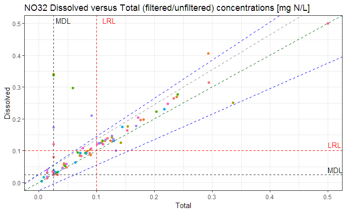

```r
# NO32_poly <- data.frame(x=c(0, 0.025, 0.025, 0),
                        # y=c(0,0,0.025, 0.025))
N_data02 %>%
  filter(ParamX=="NO32" & ACT.depth != "Bottom") %>%
  mutate(
    RVal2 = case_when(
      !is.na(Result.Value) ~ as.numeric(Result.Value),
      is.na(Result.Value) & !is.na(MDL) ~ as.numeric(MDL),
      is.na(Result.Value) & !is.na(LRL) ~ as.numeric(LRL),
      TRUE ~ as.numeric(NA)),
    Rflag = case_when(
      is.na(Result.Value) & !is.na(MDL) ~ "U",
      is.na(Result.Value) & !is.na(LRL) ~ "J",
      TRUE ~ as.character(NA))
    ) %>%
  distinct(MLID, ParamX, SDate, SampFrac, RVal2, ACT.depth,
         MethodID) %>%
  spread(., SampFrac, RVal2) %>%
  ggplot(.,
         aes(x=Total, y=Dissolved,
             col=MLID)) + theme_bw() +
  geom_point(na.rm=T) + theme(legend.position = "none") +
  ggtitle("NO32 Dissolved versus Total (filtered/unfiltered) concentrations [mg N/L]") +
  geom_abline(slope=1, intercept=0, lty=2, col="darkgreen") +
  geom_abline(slope = 1.1, intercept = 0.025, lty=2, col="gray40", alpha=0.8) +
  geom_abline(slope=1.2, intercept=0.025, lty=2, col="blue") +
  geom_abline(slope=0.8, intercept=-0.025, lty=2, col="blue") +
  scale_x_continuous(limits=c(0, 0.5), oob=squish) +
  scale_y_continuous(limits=c(0, 0.5), oob=squish) +
  geom_hline(yintercept=0.1, lty=2, col="red") +
  geom_vline(xintercept=0.1, lty=2, col="red") +
  geom_hline(yintercept = 0.025, lty=2, col="gray20") +
  geom_vline(xintercept = 0.025, lty=2, col="gray20") +
  annotate("text", x=0.11, y=0.5, vjust=0, hjust=0, label="LRL", col="red") +
  annotate("text", x=0.5, y=0.11, vjust=0, hjust=0, label="LRL", col="red") +
  annotate("text", x=0.03, y=0.5, vjust=0, hjust=0, label="MDL") +
  annotate("text", x=0.5, y=0.03, vjust=0, hjust=0, label="MDL")
```

```r
#geom_polygon(data=NO32_poly, aes(x=x, y=y), fill="gray70", alpha=0.5) +
```

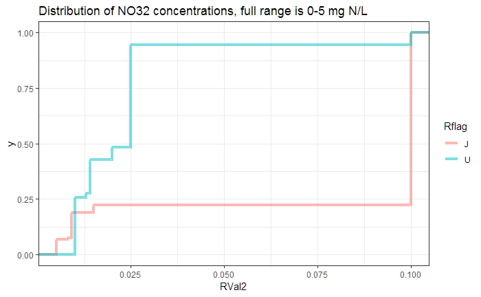

```r
N_data02 %>%
  filter(ParamX=="NO32" & ACT.depth != "Bottom") %>%
  mutate(
    RVal2 = case_when(
      !is.na(Result.Value) ~ as.numeric(Result.Value),
      is.na(Result.Value) & !is.na(MDL) ~ as.numeric(MDL),
      is.na(Result.Value) & !is.na(LRL) ~ as.numeric(LRL),
      TRUE ~ as.numeric(NA)),
    Rflag = case_when(
      is.na(Result.Value) & !is.na(MDL) ~ "U",
      is.na(Result.Value) & !is.na(LRL) ~ "J",
      TRUE ~ as.character(NA))
    ) %>%
  filter(!is.na(Rflag)) %>%
  ggplot(.,
         aes(x=RVal2, col=Rflag)) + theme_bw() +
  stat_ecdf(na.rm=T, lty=1, alpha=0.5, size=1.5) +
  ggtitle("Distribution of NO32 concentrations, full range is 0-5 mg N/L") +
  scale_x_continuous(oob=squish, limits=c(NA, NA))
```

#### Total N x Sample Fraction

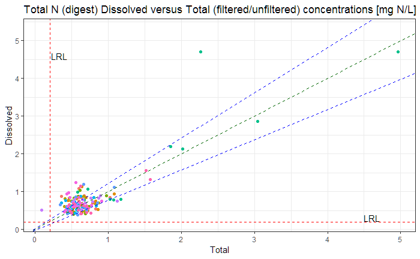

```r
N_data02 %>%
  filter(ParamX=="TN" & ACT.depth != "Bottom") %>%
  mutate(
    RVal2 = case_when(
      !is.na(Result.Value) ~ as.numeric(Result.Value),
      is.na(Result.Value) & !is.na(MDL) ~ as.numeric(MDL),
      is.na(Result.Value) & !is.na(LRL) ~ as.numeric(LRL),
      TRUE ~ as.numeric(NA)),
    Rflag = case_when(
      is.na(Result.Value) & !is.na(MDL) ~ "U",
      is.na(Result.Value) & !is.na(LRL) ~ "J",
      TRUE ~ as.character(NA))
    ) %>%
  distinct(MLID, ParamX, SDate, SampFrac, RVal2, ACT.depth,
         MethodID) %>%
  spread(., SampFrac, RVal2) %>%
  ggplot(.,
         aes(x=Total, y=Dissolved,
             col=MLID)) + theme_bw() +
  geom_point(na.rm=T) + theme(legend.position = "none") +
  ggtitle("Total N (digest) Dissolved versus Total (filtered/unfiltered) concentrations [mg N/L]") +
  geom_abline(slope=1, intercept=0, lty=2, col="darkgreen") +
  geom_abline(slope=1.2, intercept=0.025, lty=2, col="blue") +
  geom_abline(slope=0.8, intercept=-0.025, lty=2, col="blue") +
  scale_x_continuous(limits=c(NA, NA), oob=squish) +
  scale_y_continuous(limits=c(NA, NA), oob=squish) +
  geom_hline(yintercept=0.2, lty=2, col="red") +
  geom_vline(xintercept=0.2, lty=2, col="red") +
  annotate("text", x=0.22, y=4.5, vjust=0, hjust=0, label="LRL") +
  annotate("text", x=4.5, y=0.22, vjust=0, hjust=0, label="LRL")
```

*Take another closer look*

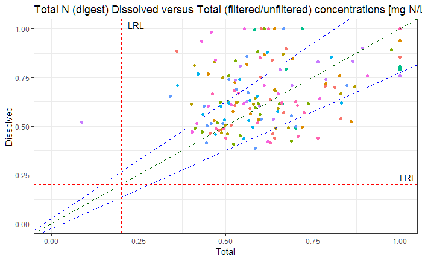

```r
N_data02 %>%
  filter(ParamX=="TN" & ACT.depth != "Bottom") %>%
  mutate(
    RVal2 = case_when(
      !is.na(Result.Value) ~ as.numeric(Result.Value),
      is.na(Result.Value) & !is.na(MDL) ~ as.numeric(MDL),
      is.na(Result.Value) & !is.na(LRL) ~ as.numeric(LRL),
      TRUE ~ as.numeric(NA)),
    Rflag = case_when(
      is.na(Result.Value) & !is.na(MDL) ~ "U",
      is.na(Result.Value) & !is.na(LRL) ~ "J",
      TRUE ~ as.character(NA))
    ) %>%
  distinct(MLID, ParamX, SDate, SampFrac, RVal2, ACT.depth,
         MethodID) %>%
  spread(., SampFrac, RVal2) %>%
  ggplot(.,
         aes(x=Total, y=Dissolved,
             col=MLID)) + theme_bw() +
  geom_point(na.rm=T) + theme(legend.position = "none") +
  ggtitle("Total N (digest) Dissolved versus Total (filtered/unfiltered) concentrations [mg N/L]") +
  geom_abline(slope=1, intercept=0, lty=2, col="darkgreen") +
  geom_abline(slope=1.2, intercept=0.025, lty=2, col="blue") +
  geom_abline(slope=0.8, intercept=-0.025, lty=2, col="blue") +
  scale_x_continuous(limits=c(0, 1), oob=squish) +
  scale_y_continuous(limits=c(0, 1), oob=squish) +
  geom_hline(yintercept=0.2, lty=2, col="red") +
  geom_vline(xintercept=0.2, lty=2, col="red") +
  annotate("text", x=0.22, y=4.5, vjust=0, hjust=0, label="LRL") +
  annotate("text", x=4.5, y=0.22, vjust=0, hjust=0, label="LRL")
```

- Take a quick look at how the rest of the collected samples vary…

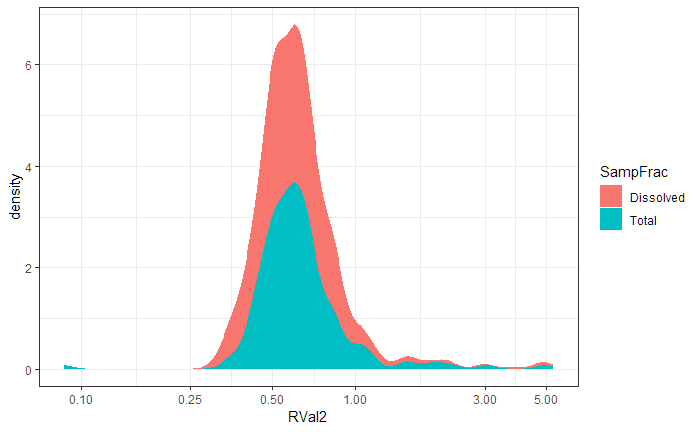

```r
N_data02 %>%
  filter(ParamX=="TN" & ACT.depth != "Bottom") %>%
  mutate(
    RVal2 = case_when(
      !is.na(Result.Value) ~ as.numeric(Result.Value),
      is.na(Result.Value) & !is.na(MDL) ~ as.numeric(MDL),
      is.na(Result.Value) & !is.na(LRL) ~ as.numeric(LRL),
      TRUE ~ as.numeric(NA)),
    Rflag = case_when(
      is.na(Result.Value) & !is.na(MDL) ~ "U",
      is.na(Result.Value) & !is.na(LRL) ~ "J",
      TRUE ~ as.character(NA))
    ) %>%
  ggplot(.,
         aes(x=RVal2, fill=SampFrac)) + theme_bw() +
  stat_density(na.rm=T) +
  scale_x_continuous(limits=c(NA, NA), trans = "log10",
                     breaks=c(0.01, 0.025, 0.1, 0.25, 0.5, 1, 3, 5))
```

## END

### Working pieces

```r
# select(EDD2_2, contains("key", ignore.case=T)) %>% names(.)
```

**Start work date ::** 190711  
**Last work date ::** 190715  
**Current review date ::** 190715

eof